# EDA and Applications with the Combined Bank Loan Data:

Joshua Grant

2024-03-02

# 1

Observations with missing values for the variable MIS_Status are removed from the data set

# 2

All commas and dollar signs are removed from currency counts

# 3

The Sparse categorical variable “Bank” was reduced by grouping all banks not in the top ten for loan application counts into a single group called “BANK NOT IN TOP 10”. In this data set the top 10 banks by loan application count were the 10 that received over 10,000 loan applications. After reduction the categorical variable “Bank” has 11 categories, the 10 top banks and the “BANK NOT IN THE TOP 10” category.

```
##                              Bank      n
## 1              BANK NOT IN TOP 10 535449
## 2      BANK OF AMERICA NATL ASSOC  86773
## 3                       BBCN BANK  22978
## 4          CAPITAL ONE NATL ASSOC  22247
## 5        CITIZENS BANK NATL ASSOC  33770
## 6  JPMORGAN CHASE BANK NATL ASSOC  48131
## 7   MANUFACTURERS & TRADERS TR CO  11242
## 8  PNC BANK, NATIONAL ASSOCIATION  27340
## 9           READYCAP LENDING, LLC  10664
## 10 U.S. BANK NATIONAL ASSOCIATION  35112
## 11    WELLS FARGO BANK NATL ASSOC  63461
```

# 4

This table gives the default percentages for the 11 categories of banks.

```
## # A tibble: 11 × 2
##    Bank                           Default_Rate
##    <chr>                                 <dbl>
##  1 BANK NOT IN TOP 10                     12.4
##  2 BANK OF AMERICA NATL ASSOC             27.6
##  3 BBCN BANK                              55.0
##  4 CAPITAL ONE NATL ASSOC                 41.3
##  5 CITIZENS BANK NATL ASSOC               22.3
##  6 JPMORGAN CHASE BANK NATL ASSOC         27.5
##  7 MANUFACTURERS & TRADERS TR CO          12.9
##  8 PNC BANK, NATIONAL ASSOCIATION         19.5
##  9 READYCAP LENDING, LLC                  26.6
## 10 U.S. BANK NATIONAL ASSOCIATION         17.5
## 11 WELLS FARGO BANK NATL ASSOC            14.1
```

# 5

In discretizing the numeric variable GrAppv, I broke the loan applications into 5 groups based on density distribution of GRAppv. For the cutoffs between groups i used the 0.2,0.4,0.6, and 0.8 percentage quantiles to separate the observation into 5 groups based on GRAppv. This way there was a roughly equal amount of observations in each of the 5 groups.

```
##    20%    40%    60%    80%
##  25200  57000 121200 287000
```

```
##   GRAppv_Dis      n
## 1       High 179429
## 2    Highest 179440
## 3        Low 179369
## 4     Lowest 179366
## 5     Middle 179563
```

# 6

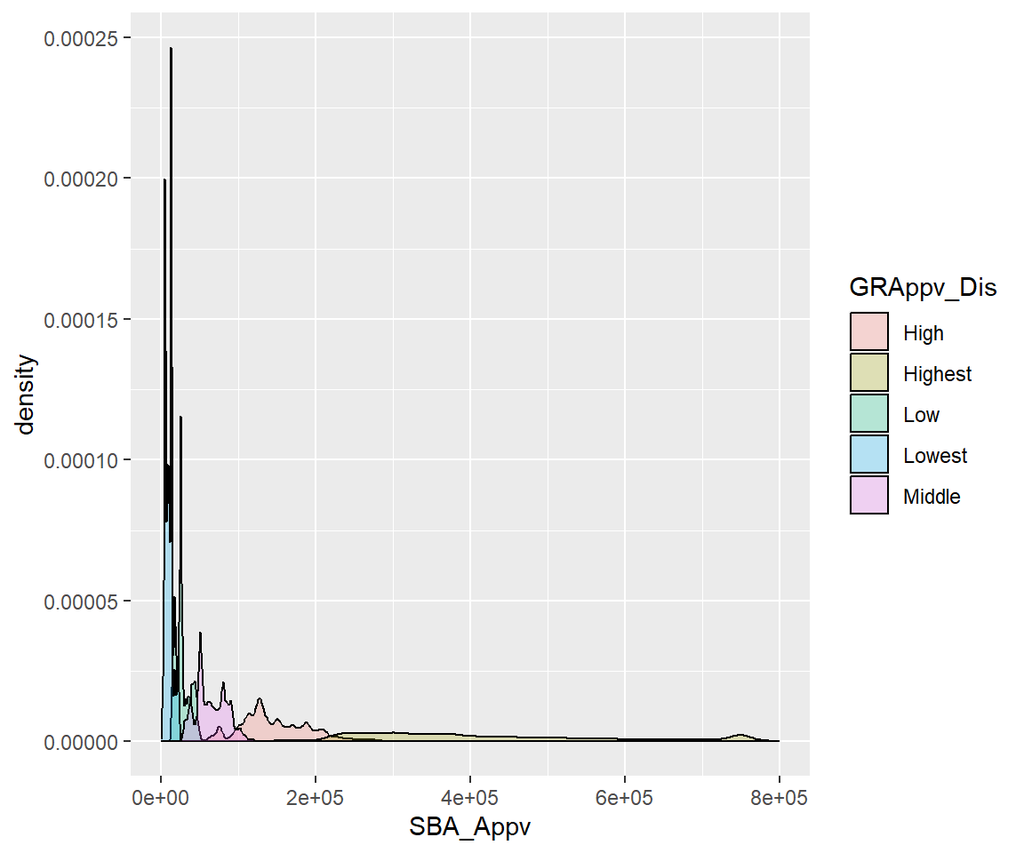